# Portfolio

### Question

> `Reyeme Affiare`는 Boston에서 여러 시간에 걸쳐 좋은 집을 구하고자 하였고 드디어 괜찮은 집을 찾은듯 하다. 하지만 어느정도 가격에 이 집을 구매하는것이 좋을지 확신이 없다. 어느 가격으로 `236 Ellery Street Cambridge` 의 집을 구매하는것이 좋을까 ?

### 1. 데이터 확인

#### 모든 분석은 R을 통해 진행된다. `Reyeme Affiare`이 힘들게 찾아낸 `236 Ellery Street Cambridge`의 Sweet Home에 대한 정보는 다음과 같다.

| 변수명 | 값 |
| --- | --- |
| **Rooms** | 5 |
| **Bedroom** | 2 |
| **Bath** | 1 |
| **Location** | M |
| **Interior Space** | 1040 |
| **Monthly Condominium Fee** | $175 |
| **Annual Property Taxes** | $1121 |
| **Price** | $169000 |
| **Put on Market** | 1994-05-04 |

> 해당 지역 거래가격 데이터의 간단한 `EDA` 는 다음과 같다

```r
rey = read.csv('~/RLectureData/leyme.csv', header=T)
attributes(rey)
```

[output not shown]

[output cut: 21 more lines]

```r
rey_del=rey[-c(1,2,4,8)]
names(rey_del)
```

```
##  [1] "Area"       "FirstPrice" "LastPrice"  "SalePrice"  "CloseDate"
##  [6] "Days"       "Interior"   "Bed"        "Bath"       "Rooms"
## [11] "Condo"      "Tax"        "RC"
```

```r
str(rey_del)
```

```
## 'data.frame':    456 obs. of  13 variables:
##  $ Area      : chr  "CP" "CP" "M" "M" ...
##  $ FirstPrice: num  109000 127000 123000 219000 199000 ...
##  $ LastPrice : num  109000 127000 100000 210000 189000 ...
##  $ SalePrice : num  106000 125000 95000 206000 175000 ...
##  $ CloseDate : chr  "10/22/93" "10/22/93" "9/30/93" "8/23/91" ...
##  $ Days      : int  97 62 208 159 110 116 160 80 157 123 ...
##  $ Interior  : int  834 850 730 1460 1630 1225 1585 1058 1446 1330 ...
##  $ Bed       : int  2 2 2 3 4 2 2 3 3 3 ...
##  $ Bath      : int  1 1 1 2 1 1 1 1 1 1 ...
##  $ Rooms     : int  4 5 4 6 8 6 6 5 6 6 ...
##  $ Condo     : int  70 100 185 100 50 100 100 163 150 100 ...
##  $ Tax       : int  490 923 575 1582 1659 1698 1402 1682 2120 1590 ...
##  $ RC        : int  0 1 0 1 1 1 1 0 1 1 ...
```

```r
dim(rey_del)
```

```
## [1] 456  13
```

```r
head(rey_del)
```

```
##   Area FirstPrice LastPrice SalePrice CloseDate Days Interior Bed Bath Rooms
## 1   CP     109000    109000    106000  10/22/93   97      834   2    1     4
## 2   CP     127000    127000    125000  10/22/93   62      850   2    1     5
## 3    M     123000    100000     95000   9/30/93  208      730   2    1     4
## 4    M     219000    210000    206000   8/23/91  159     1460   3    2     6
## 5    M     199000    189000    175000   9/15/92  110     1630   4    1     8
## 6    M     169000    152000    136500   9/23/92  116     1225   2    1     6
##   Condo  Tax RC
## 1    70  490  0
## 2   100  923  1
## 3   185  575  0
## 4   100 1582  1
## 5    50 1659  1
## 6   100 1698  1
```

```r
table(is.na(rey_del))
```

```
##
## FALSE
##  5928
```

> 데이터의 숫자는 `456`, 변수의 숫자는 `13`이다. 결측치는 관찰되지 않으며 변수들 중 `Area`, `Rent Control`, `Days`변수의 경우 `Dummy Variable`처리를 하여 살펴볼 필요가 보인다.

### 2. 다중회귀분석

#### 2.1 모델 선택

#### 먼저 모든 변수를 고려한 다중회귀분석을 실시해본다. 그전 `CloseDate`변수의 경우 연도별로 변수를 바꾸어 준 후 분석을 실시해본다.

```r
year = as.Date(rey_del$CloseDate, "%m/%d/%Y")
library(lubridate)
year1 = year[c(1:456)]+years(1900)
rey_del$CloseDate=year1
year2 = substr(as.character(rey_del$CloseDate, "%Y-%m-%d"), 1,4)
rey_del_cbind=cbind(rey_del, year2)
```

> `closedate`를 기준으로 날짜 변환을 하였으나 원데이터 상 `91`, `93`등으로 년도가 축소되어 있었음으로 `1900`을 추가하여 원래 년도로 맞추어 주었다. 그 후 `year`만을 추출하여 현재 데이터에 추가해주었다.

```r
library(car)
model1 = lm(data=rey_del_cbind, SalePrice ~ Area+FirstPrice+LastPrice+Days+Interior+Bed+Bath+Rooms+ year2)
summary(model1)
```

```
##
## Call:
## lm(formula = SalePrice ~ Area + FirstPrice + LastPrice + Days +
##     Interior + Bed + Bath + Rooms + year2, data = rey_del_cbind)
##
## Residuals:
##    Min     1Q Median     3Q    Max
## -44424  -3182    461   3737  55631
##
## Coefficients:
##               Estimate Std. Error t value Pr(>|t|)
## (Intercept)  4.789e+03  3.336e+03   1.435  0.15192
## AreaAH       3.826e+02  2.817e+03   0.136  0.89205
## AreaC       -6.889e+03  4.795e+03  -1.437  0.15157
## AreaCP      -2.553e+03  2.989e+03  -0.854  0.39345
## AreaE       -1.276e+04  3.039e+03  -4.199 3.26e-05 ***
## AreaFP      -8.702e+03  6.255e+03  -1.391  0.16489
## AreaHS      -2.970e+03  2.664e+03  -1.115  0.26546
## AreaK       -6.364e+03  3.153e+03  -2.018  0.04419 *
## AreaM       -1.438e+03  2.562e+03  -0.561  0.57492
## AreaN       -6.670e+03  3.227e+03  -2.067  0.03938 *
## AreaNW      -1.717e+03  4.393e+03  -0.391  0.69610
## AreaPS      -8.516e+01  3.289e+03  -0.026  0.97936
## AreaRA      -5.758e+02  2.775e+03  -0.207  0.83573
## AreaRS      -1.217e+03  3.231e+03  -0.377  0.70665
## AreaSH      -4.906e+03  4.225e+03  -1.161  0.24619
## AreaW       -1.212e+03  2.820e+03  -0.430  0.66753
## FirstPrice  -7.181e-02  1.933e-02  -3.715  0.00023 ***
## LastPrice    1.006e+00  2.030e-02  49.565  < 2e-16 ***
## Days         8.466e-01  3.007e+00   0.282  0.77842
## Interior     3.586e+00  2.524e+00   1.421  0.15604
## Bed          9.403e+02  1.066e+03   0.882  0.37816
## Bath        -1.026e+03  1.026e+03  -1.000  0.31794
## Rooms       -6.226e+02  7.563e+02  -0.823  0.41083
## year21991   -1.162e+03  1.316e+03  -0.883  0.37765
## year21992   -1.159e+03  1.317e+03  -0.880  0.37955
## year21993   -3.062e+02  1.216e+03  -0.252  0.80125
## year21994   -7.542e-01  1.673e+03   0.000  0.99964
## ---
## Signif. codes:  0 '***' 0.001 '**' 0.01 '*' 0.05 '.' 0.1 ' ' 1
##
## Residual standard error: 8029 on 429 degrees of freedom
## Multiple R-squared:  0.9924, Adjusted R-squared:  0.992
## F-statistic:  2167 on 26 and 429 DF,  p-value: < 2.2e-16
```

```r
vif(model1)
```

```
##                 GVIF Df GVIF^(1/(2*Df))
## Area        3.308754 15        1.040692
## FirstPrice 26.611116  1        5.158596
## LastPrice  27.090583  1        5.204861
## Days        1.265471  1        1.124931
## Interior    5.344806  1        2.311884
## Bed         4.055353  1        2.013791
## Bath        1.970077  1        1.403594
## Rooms       5.193305  1        2.278882
## year2       1.462538  4        1.048669
```

> 먼저 전체 모델을 해본 결과 `adjusted r-squared`가 `0.992`로 매우 높게 나왔고 `AreaE`, `Areak`, `AreaN`, `FirstPrice`, `LastPrice`가 유의미하게 나오게 되었다. 하지만 이 값들이 유효하다고 보기는 어렵다. 왜냐하면 현재 우리가 구하고자 하는 지역은 `M`지역이다. 하지만 타 지역이 유효하게 도출되었고 `FirstPrice`와 `LastPrice`는 당연히 큰 공선성이 존재하리라 판단되기 때문이다. 따라서 `FirstPrice`와 `LastPrice`를 제외한 나머지 변수들을 이용해 모델 선택을 진행 후 최적 모델에 대해서 살펴볼 예정이다.

```r
library(MASS)
start.model = lm(data=rey_del_cbind, SalePrice ~ Area)
stepAIC(start.model, scope=list(upper=~Area+year2+Days+Interior+Condo+Tax+RC+Bed+Bath+Rooms, lower=~Area), direction='both')
```

```
## Start:  AIC=10326.08
## SalePrice ~ Area
##
##            Df  Sum of Sq        RSS   AIC
## + Tax       1 2.1134e+12 7.9097e+11  9735
## + Interior  1 1.4573e+12 1.4470e+12 10010
## + Condo     1 1.2450e+12 1.6594e+12 10073
## + Rooms     1 7.7639e+11 2.1280e+12 10186
## + Bath      1 7.3515e+11 2.1692e+12 10195
## + Bed       1 7.2984e+11 2.1745e+12 10196
## + RC        1 1.2064e+11 2.7837e+12 10309
## <none>                   2.9044e+12 10326
## + Days      1 2.8544e+07 2.9043e+12 10328
## + year2     4 1.3392e+10 2.8910e+12 10332
##
## Step:  AIC=9734.96
## SalePrice ~ Area + Tax
##
##            Df  Sum of Sq        RSS     AIC
## + Interior  1 1.3574e+11 6.5523e+11  9651.1
## + Rooms     1 5.3116e+10 7.3786e+11  9705.3
## + Bed       1 3.6738e+10 7.5424e+11  9715.3
## + Condo     1 3.1874e+10 7.5910e+11  9718.2
## + year2     4 3.7249e+10 7.5373e+11  9721.0
## + Bath      1 2.4112e+10 7.6686e+11  9722.8
## + Days      1 1.6720e+10 7.7425e+11  9727.2
## + RC        1 1.0023e+10 7.8095e+11  9731.1
## <none>                   7.9097e+11  9735.0
## - Tax       1 2.1134e+12 2.9044e+12 10326.1
##
## Step:  AIC=9651.11
## SalePrice ~ Area + Tax + Interior
##
##            Df  Sum of Sq        RSS     AIC
## + Condo     1 6.0930e+10 5.9430e+11  9608.6
## + year2     4 2.4016e+10 6.3121e+11  9642.1
## + RC        1 8.1324e+09 6.4710e+11  9647.4
## + Days      1 7.9984e+09 6.4723e+11  9647.5
## + Bed       1 3.4653e+09 6.5177e+11  9650.7
## + Rooms     1 2.9587e+09 6.5227e+11  9651.0
```

[output cut: 49 more lines]

```
##
## Step:  AIC=9589.53
## SalePrice ~ Area + Tax + Interior + Condo + year2 + RC + Days
##
##            Df  Sum of Sq        RSS    AIC
## <none>                   5.5516e+11 9589.5
## + Bath      1 2.0711e+08 5.5495e+11 9591.4
## + Rooms     1 1.3655e+08 5.5502e+11 9591.4
## + Bed       1 4.5787e+07 5.5511e+11 9591.5
## - Days      1 6.2290e+09 5.6139e+11 9592.6
## - RC        1 8.0725e+09 5.6323e+11 9594.1
## - year2     4 2.1193e+10 5.7635e+11 9598.6
## - Condo     1 6.2993e+10 6.1815e+11 9636.5
## - Interior  1 1.4217e+11 6.9733e+11 9691.5
## - Tax       1 2.9775e+11 8.5291e+11 9783.3
```

```
##
## Call:
## lm(formula = SalePrice ~ Area + Tax + Interior + Condo + year2 +
##     RC + Days, data = rey_del_cbind)
##
## Coefficients:
## (Intercept)       AreaAH        AreaC       AreaCP        AreaE       AreaFP
##    -6252.73     19871.31    -32563.53     -6229.71     52714.84      2332.68
##      AreaHS        AreaK        AreaM        AreaN       AreaNW       AreaPS
##     5285.10     -8667.62      2691.11     -9406.10     -4372.01     -6863.29
##      AreaRA       AreaRS       AreaSH        AreaW          Tax     Interior
##    12401.82       539.40      4429.51    -14265.54        54.04        72.73
##       Condo    year21991    year21992    year21993    year21994           RC
##      180.68    -18680.47    -21819.13    -17489.03    -21974.59     11202.91
##        Days
##      -27.85
```

#### 2.2 Classical Assumption

#### `OLS`의 `고전 가정`은 다음과 같다.

| 가정 | 요약 | 설명 |
| --- | --- | --- |
| **가정1** | 모형구성에 대한 가정 | 가정한 회귀모형이 맞는 모형 |
| **가정2** | 측정오차에 대한 가정 | 종속변수인 Y에 대한 측정오차로 구분되는 오차의 평균은 0이다 |
| **가정3** | 정규성 가정 | 측정오차는 정규분포를 따른다 |
| **가정4** | 등분산성 가정 | 측정오차에 대한 분산은 Y가 어떠한 수준의 값을 가져도 일정한 표준편차를 갖는다. |
| **가정5** | 독립성에 대한 가정 | 측정오차는 독립적으로 관측된다 |

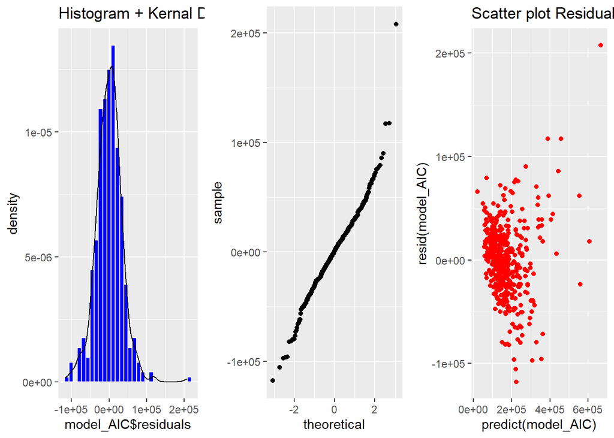

```r
library(gridExtra)
library(ggplot2)
library(ggpubr)
model_AIC=lm(data=rey_del_cbind, SalePrice~Area + Tax + Interior + Condo + year2 + RC + Days + Bed + Bath + Rooms)
p1 = ggplot(model_AIC, aes(x=model_AIC$residuals, y=..density..)) +     geom_histogram(fill='blue', colour='white')+
  geom_density(fill=NA, colour=NA)+
  geom_line(stat="density")+
  ggtitle('Histogram + Kernal Density Curve Residual')

p2 = ggplot(model_AIC, aes(x=predict(model_AIC), y=resid(model_AIC))) +
  geom_point(colour="red")+
  ggtitle('Scatter plot Residuals')

p3 = ggplot(model_AIC, aes(sample=resid(model_AIC))) +
  stat_qq()

grid.arrange(p1, p3, p2, ncol=3)
```

```r
shapiro.test(resid(model_AIC))
```

```
##
##  Shapiro-Wilk normality test
##
## data:  resid(model_AIC)
## W = 0.97181, p-value = 1.074e-07
```

```r
library(car)
ncvTest(model_AIC)
```

```
## Non-constant Variance Score Test
## Variance formula: ~ fitted.values
## Chisquare = 221.7624, Df = 1, p = < 2.22e-16
```

> plot상으로 `정규성 가정`에 문제가 있는듯 보인다. 추가로 잔차의 산점도에서 문제가 있어 보인다. `shapiro test`결과 `정규성`에 문제가 발생하였고 `Breusch-Pagan Test` 결과에 따라 이분산성이 나타나는것으로 보인다. 여기서 우리는 1. $Y$ 변환 등의 방법을 고려하거나 2. `GLS`, `WLS`등을 활용하여 분산을 정상화 시키는 방법을 고려할 수 있다.본 연구에서는 $Y$ 변환을 고려해 보겠다.

#### 2.4 $Y$ 변환

| 잔차와 Y관계 | 해결방안 |
| --- | --- |
| 1. 잔차의 분산이 $Y$의값과 비례하는 경우 | $\sqrt{Y}$변환 사용 |
| 2. 잔차의 표준편차가 $Y$의 값과 비례하는 경우 | $\log(Y)$변환 사용 |
| 3. 잔차의 표준편차가 $Y^2$의 값과 비례하는 경우 | $1/Y$변환 사용 |

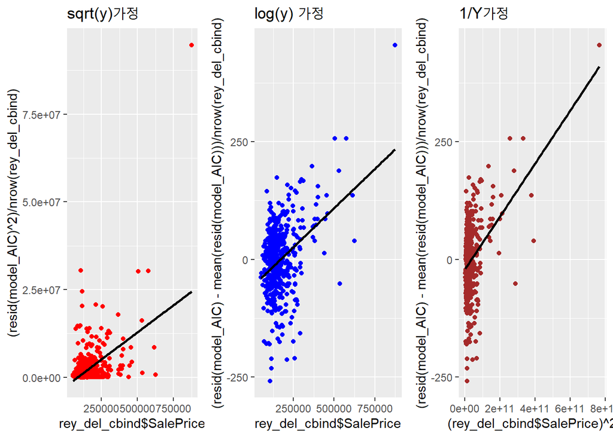

```r
library(Metrics)
p_resid1=ggplot(model_AIC, aes(x=rey_del_cbind$SalePrice, y=(resid(model_AIC)^2)/nrow(rey_del_cbind))) +
  geom_point(colour="red")+
  stat_smooth(method='lm', se=F, color='black')+
  ggtitle('sqrt(y)가정')

p_resid2=ggplot(model_AIC, aes(x=rey_del_cbind$SalePrice, y=(resid(model_AIC)-mean(resid(model_AIC)))/nrow(rey_del_cbind))) +
  geom_point(colour="blue")+
  stat_smooth(method='lm', se=F, color='black')+
  ggtitle('log(y) 가정')

p_resid3=ggplot(model_AIC, aes(x=(rey_del_cbind$SalePrice)^2, y=(resid(model_AIC)-mean(resid(model_AIC)))/nrow(rey_del_cbind))) +
  geom_point(colour="brown")+
  stat_smooth(method='lm', se=F, color='black')+
  ggtitle('1/Y가정')

grid.arrange(p_resid1, p_resid2, p_resid3, ncol=3)
```

> 해당 그래프를 살펴보면 $\log(Y)$ 변환과 $1/Y$변환의 경우 별로 올바르지 못한것으로 보인다. 따라서 $\sqrt{Y}$변환이 가장 올바른것으로 판단된다. 하지만 $\log(Y)$ 변환과 $1/Y$변환 모두 진행해 보겠다.

#### 2.4.A $\sqrt{Y}$변환

```r
rey_del_cbind1=rey_del_cbind
sqrt_sale=sqrt(rey_del_cbind1$SalePrice)
rey_del_cbind1$SalePrice=sqrt_sale
start.model=lm(data=rey_del_cbind1, SalePrice~Area)
stepAIC(start.model, scope=list(upper=~Area+year2+Days+Interior+Condo+Tax+RC+Bed+Bath+Rooms, lower=~Area), direction='both')
```

```
## Start:  AIC=4065.05
## SalePrice ~ Area
##
##            Df Sum of Sq     RSS    AIC
## + Tax       1   2219769  942788 3515.2
## + Interior  1   1810269 1352288 3679.6
## + Condo     1   1197630 1964927 3850.0
## + Rooms     1   1060687 2101870 3880.7
## + Bed       1    963623 2198934 3901.3
## + Bath      1    866988 2295569 3920.9
## + RC        1    154483 3008074 4044.2
## <none>                  3162557 4065.0
## + Days      1      2330 3160228 4066.7
## + year2     4     11097 3151461 4071.4
##
## Step:  AIC=3515.15
## SalePrice ~ Area + Tax
##
##            Df Sum of Sq     RSS    AIC
## + Interior  1    267960  674829 3364.7
## + Rooms     1    144069  798719 3441.5
## + Bed       1    100322  842466 3465.8
## + Bath      1     48192  894596 3493.2
## + year2     4     46402  896386 3500.1
## + Days      1     30789  912000 3502.0
## + Condo     1     13495  929293 3510.6
## <none>                   942788 3515.2
## + RC        1      4056  938733 3515.2
## - Tax       1   2219769 3162557 4065.0
##
## Step:  AIC=3364.67
## SalePrice ~ Area + Tax + Interior
##
##            Df Sum of Sq     RSS    AIC
## + Condo     1     44111  630717 3335.8
## + year2     4     26858  647971 3354.2
## + Days      1     14258  660570 3356.9
## <none>                   674829 3364.7
## + RC        1      2470  672358 3365.0
## + Bed       1       432  674396 3366.4
```

[output cut: 49 more lines]

```
##
## Step:  AIC=3315.13
## SalePrice ~ Area + Tax + Interior + Condo + year2 + Days + Rooms
##
##            Df Sum of Sq    RSS    AIC
## <none>                  587045 3315.1
## - Rooms     1      2960 590005 3315.4
## + RC        1      1589 585456 3315.9
## + Bed       1       100 586945 3317.0
## + Bath      1        10 587035 3317.1
## - Days      1     13381 600426 3323.4
## - year2     4     24467 611512 3325.7
## - Condo     1     50082 637127 3350.5
## - Interior  1    103077 690121 3386.9
## - Tax       1    259390 846434 3480.0
```

```
##
## Call:
## lm(formula = SalePrice ~ Area + Tax + Interior + Condo + year2 +
##     Days + Rooms, data = rey_del_cbind1)
##
## Coefficients:
## (Intercept)       AreaAH        AreaC       AreaCP        AreaE       AreaFP
##   219.44547     19.91530    -51.04636    -22.42361     35.80745     -7.61917
##      AreaHS        AreaK        AreaM        AreaN       AreaNW       AreaPS
##     0.38468    -16.93641     -3.98938    -25.49357    -11.59310    -24.14573
##      AreaRA       AreaRS       AreaSH        AreaW          Tax     Interior
##    14.09024    -12.07015    -34.79853    -14.04064      0.04949      0.08878
##       Condo    year21991    year21992    year21993    year21994         Days
##     0.16426    -21.41168    -22.07793    -21.18209    -18.63830     -0.04091
##       Rooms
##     4.03541
```

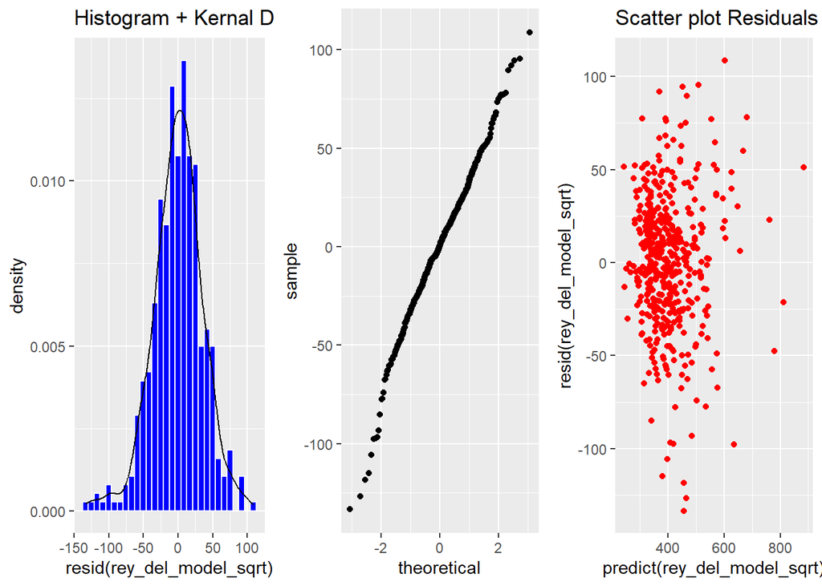

```r
rey_del_model_sqrt=lm(data=rey_del_cbind1, SalePrice~Area + Tax + Interior + Condo + year2 + Days + Rooms)

p1 = ggplot(rey_del_model_sqrt, aes(resid(rey_del_model_sqrt), y=..density..)) +     geom_histogram(fill='blue', colour='white')+
  geom_density(fill=NA, colour=NA)+
  geom_line(stat="density")+
  ggtitle('Histogram + Kernal Density Curve Residual')

p2 = ggplot(rey_del_model_sqrt, aes(x=predict(rey_del_model_sqrt), y=resid(rey_del_model_sqrt))) +
  geom_point(colour="red")+
  ggtitle('Scatter plot Residuals')
p3 = ggplot(rey_del_model_sqrt, aes(sample=resid(rey_del_model_sqrt))) +
  stat_qq()

grid.arrange(p1, p3, p2, ncol=3)
```

```r
shapiro.test(resid(rey_del_model_sqrt))
```

```
##
##  Shapiro-Wilk normality test
##
## data:  resid(rey_del_model_sqrt)
## W = 0.98741, p-value = 0.0005614
```

```r
library(car)
ncvTest(rey_del_model_sqrt)
```

```
## Non-constant Variance Score Test
## Variance formula: ~ fitted.values
## Chisquare = 25.39202, Df = 1, p = 4.6785e-07
```

> `정상성`과 `등분상성` 모두 충족시키지 못한다. 추가적으로 $\log(Y)$변환 또한 살펴보겠다.

#### 2.4.B $\log(Y)$ 변환

```r
rey_del_cbind2=rey_del_cbind
log_sale=log(rey_del_cbind2$SalePrice)
rey_del_cbind2$SalePrice=log_sale
start.model=lm(data=rey_del_cbind2, SalePrice~Area)
stepAIC(start.model, scope=list(upper=~Area+year2+Days+Interior+Condo+Tax+RC+Bed+Bath+Rooms, lower=~Area), direction='both')
```

```
## Start:  AIC=-843.26
## SalePrice ~ Area
##
##            Df Sum of Sq    RSS      AIC
## + Tax       1    42.509 24.381 -1301.47
## + Interior  1    39.906 26.985 -1255.21
## + Rooms     1    25.276 41.614 -1057.69
## + Bed       1    22.369 44.522 -1026.89
## + Condo     1    21.073 45.818 -1013.81
## + Bath      1    17.934 48.956  -983.60
## + RC        1     3.548 63.342  -866.12
## <none>                  66.890  -843.26
## + Days      1     0.172 66.718  -842.44
## + year2     4     0.189 66.702  -836.55
##
## Step:  AIC=-1301.47
## SalePrice ~ Area + Tax
##
##            Df Sum of Sq    RSS      AIC
## + Interior  1     7.956 16.426 -1479.59
## + Rooms     1     5.060 19.322 -1405.53
## + Bed       1     3.527 20.855 -1370.72
## + Bath      1     1.312 23.070 -1324.69
## + Days      1     0.945 23.436 -1317.50
## + year2     4     1.094 23.287 -1314.42
## <none>                  24.381 -1301.47
## + Condo     1     0.057 24.325 -1300.54
## + RC        1     0.011 24.370 -1299.69
## - Tax       1    42.509 66.890  -843.26
##
## Step:  AIC=-1479.59
## SalePrice ~ Area + Tax + Interior
##
##            Df Sum of Sq    RSS     AIC
## + Condo     1    0.5533 15.872 -1493.2
## + Days      1    0.4447 15.981 -1490.1
## + year2     4    0.6030 15.823 -1488.6
## + Rooms     1    0.0840 16.342 -1479.9
## <none>                  16.426 -1479.6
## + Bed       1    0.0073 16.418 -1477.8
```

[output cut: 49 more lines]

```
##
## Step:  AIC=-1519.71
## SalePrice ~ Area + Tax + Interior + Condo + Days + year2 + Rooms
##
##            Df Sum of Sq    RSS     AIC
## <none>                  14.587 -1519.7
## + RC        1    0.0030 14.584 -1517.8
## + Bed       1    0.0019 14.585 -1517.8
## + Bath      1    0.0006 14.586 -1517.7
## - Rooms     1    0.2445 14.832 -1514.1
## - year2     4    0.5628 15.150 -1510.5
## - Days      1    0.4489 15.036 -1507.9
## - Condo     1    0.7585 15.346 -1498.6
## - Interior  1    2.4582 17.045 -1450.7
## - Tax       1    4.2831 18.870 -1404.3
```

```
##
## Call:
## lm(formula = SalePrice ~ Area + Tax + Interior + Condo + Days +
##     year2 + Rooms, data = rey_del_cbind2)
##
## Coefficients:
## (Intercept)       AreaAH        AreaC       AreaCP        AreaE       AreaFP
##  11.0879647    0.0928496   -0.2757190   -0.1395633    0.1089783   -0.0658396
##      AreaHS        AreaK        AreaM        AreaN       AreaNW       AreaPS
##  -0.0119548   -0.0853266   -0.0325807   -0.1559093   -0.0496486   -0.1321262
##      AreaRA       AreaRS       AreaSH        AreaW          Tax     Interior
##   0.0645475   -0.0942465   -0.3479379   -0.0554740    0.0002011    0.0004335
##       Condo         Days    year21991    year21992    year21993    year21994
##   0.0006392   -0.0002369   -0.0986352   -0.1013954   -0.1037608   -0.0659786
##       Rooms
##   0.0366710
```

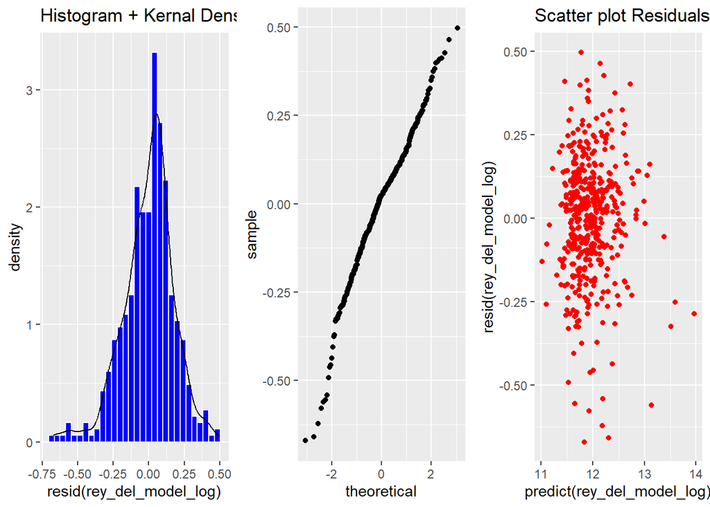

```r
rey_del_model_log=lm(data=rey_del_cbind2, SalePrice~Area + Tax + Interior + Condo + Days + year2 + Rooms)

p1 = ggplot(rey_del_model_log, aes(resid(rey_del_model_log), y=..density..)) +     geom_histogram(fill='blue', colour='white')+
  geom_density(fill=NA, colour=NA)+
  geom_line(stat="density")+
  ggtitle('Histogram + Kernal Density Curve Residual')

p2 = ggplot(rey_del_model_log, aes(x=predict(rey_del_model_log), y=resid(rey_del_model_log))) +
  geom_point(colour="red")+
  ggtitle('Scatter plot Residuals')
p3 = ggplot(rey_del_model_log, aes(sample=resid(rey_del_model_log))) +
  stat_qq()

grid.arrange(p1, p3, p2, ncol=3)
```

```r
shapiro.test(resid(rey_del_model_log))
```

```
##
##  Shapiro-Wilk normality test
##
## data:  resid(rey_del_model_log)
## W = 0.9763, p-value = 9.173e-07
```

```r
library(car)
ncvTest(rey_del_model_log)
```

```
## Non-constant Variance Score Test
## Variance formula: ~ fitted.values
## Chisquare = 3.638915, Df = 1, p = 0.056444
```

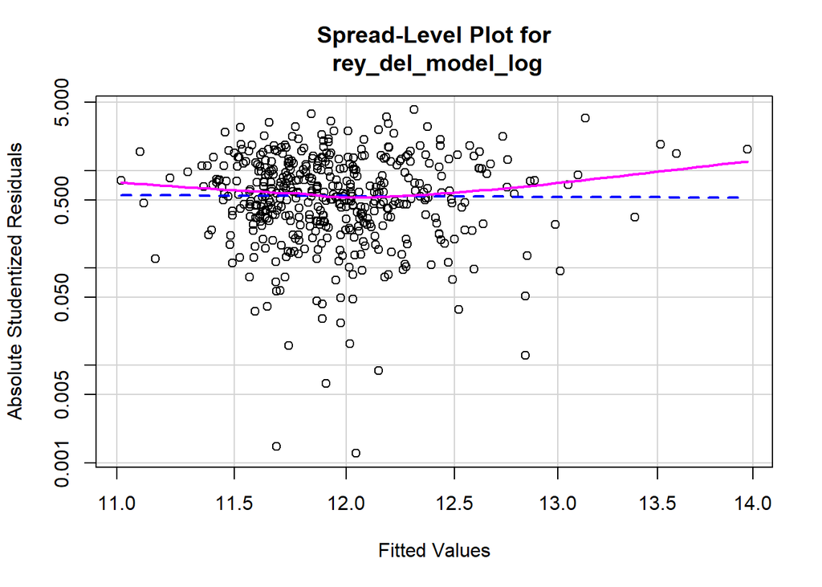

```
##
## Suggested power transformation:  1.209216
```

```r
spreadLevelPlot(rey_del_model_log)
```

> 결과 : $\log(Y)$변환을 실시한 후 `이분산 테스트`가 `0.05644`로 `등분산성`을 `만족`하는것을 볼 수 있다. 추가적으로 다음은 $1/Y$변환을 통해 살펴보겠다.

#### 2.4.C $1/Y$변환

```r
rey_del_cbind3=rey_del_cbind
div_sale=1/rey_del_cbind$SalePrice
rey_del_cbind3$SalePrice=div_sale
start.model=lm(data=rey_del_cbind3, SalePrice~Area)
stepAIC(start.model, scope=list(upper=~Area+year2+Days+Interior+Condo+Tax+RC+Bed+Bath+Rooms, lower=~Area), direction='both')
```

```
## Start:  AIC=-11720.55
## SalePrice ~ Area
##
##            Df  Sum of Sq        RSS    AIC
## + Interior  1 1.5834e-09 1.3396e-09 -12074
## + Tax       1 1.3726e-09 1.5504e-09 -12008
## + Rooms     1 1.1233e-09 1.7997e-09 -11940
## + Bed       1 9.5765e-10 1.9654e-09 -11900
## + Bath      1 6.2169e-10 2.3013e-09 -11828
## + Condo     1 5.9301e-10 2.3300e-09 -11822
## + RC        1 1.5934e-10 2.7637e-09 -11744
## + Days      1 2.2700e-11 2.9003e-09 -11722
## <none>                   2.9230e-09 -11721
## + year2     4 7.7000e-12 2.9153e-09 -11714
##
## Step:  AIC=-12074.34
## SalePrice ~ Area + Interior
##
##            Df  Sum of Sq        RSS    AIC
## + Tax       1 2.3307e-10 1.1065e-09 -12160
## + Condo     1 1.4119e-10 1.1984e-09 -12123
## + RC        1 3.3810e-11 1.3058e-09 -12084
## + Days      1 1.2600e-11 1.3270e-09 -12077
## + Rooms     1 1.0460e-11 1.3291e-09 -12076
## + Bath      1 6.1200e-12 1.3335e-09 -12074
## <none>                   1.3396e-09 -12074
## + Bed       1 5.7000e-12 1.3339e-09 -12074
## + year2     4 1.3310e-11 1.3263e-09 -12071
## - Interior  1 1.5834e-09 2.9230e-09 -11721
##
## Step:  AIC=-12159.5
## SalePrice ~ Area + Interior + Tax
##
##            Df  Sum of Sq        RSS    AIC
## + Days      1 3.2080e-11 1.0745e-09 -12171
## + Rooms     1 1.9830e-11 1.0867e-09 -12166
## + year2     4 2.9200e-11 1.0774e-09 -12164
## + Condo     1 7.4600e-12 1.0991e-09 -12161
## + Bed       1 5.2000e-12 1.1013e-09 -12160
## <none>                   1.1065e-09 -12160
```

[output cut: 65 more lines]

```
## Step:  AIC=-12190.07
## SalePrice ~ Area + Interior + Tax + Days + Rooms + Condo + year2 +
##     RC
##
##            Df  Sum of Sq        RSS    AIC
## <none>                   9.9911e-10 -12190
## + Bath      1 2.5390e-12 9.9657e-10 -12189
## - RC        1 8.2470e-12 1.0074e-09 -12188
## + Bed       1 3.3400e-13 9.9877e-10 -12188
## - year2     4 2.9583e-11 1.0287e-09 -12185
## - Condo     1 1.7841e-11 1.0170e-09 -12184
## - Rooms     1 3.4642e-11 1.0338e-09 -12176
## - Days      1 3.5322e-11 1.0344e-09 -12176
## - Tax       1 9.0586e-11 1.0897e-09 -12152
## - Interior  1 9.6305e-11 1.0954e-09 -12150
```

```
##
## Call:
## lm(formula = SalePrice ~ Area + Interior + Tax + Days + Rooms +
##     Condo + year2 + RC, data = rey_del_cbind3)
##
## Coefficients:
## (Intercept)       AreaAH        AreaC       AreaCP        AreaE       AreaFP
##   1.203e-05   -5.119e-07    1.987e-06    1.353e-06    3.096e-07    5.591e-07
##      AreaHS        AreaK        AreaM        AreaN       AreaNW       AreaPS
##   3.771e-07    1.203e-06    4.719e-07    1.432e-06    4.249e-07    1.251e-06
##      AreaRA       AreaRS       AreaSH        AreaW     Interior          Tax
##  -3.333e-07    9.912e-07    5.401e-06    3.459e-07   -2.718e-09   -9.452e-10
##        Days        Rooms        Condo    year21991    year21992    year21993
##   2.103e-09   -4.391e-07   -3.101e-09    6.070e-07    6.632e-07    7.257e-07
##   year21994           RC
##   2.045e-07    3.602e-07
```

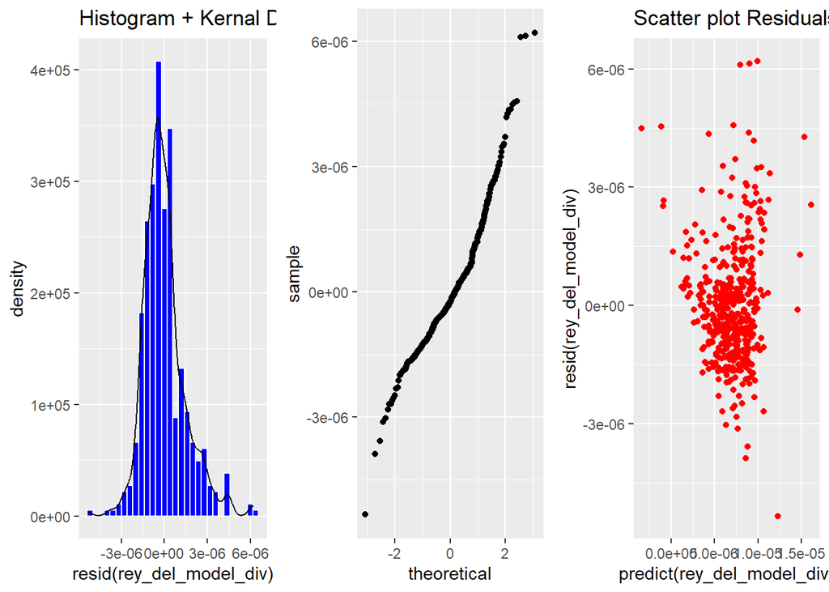

```r
rey_del_model_div=lm(data=rey_del_cbind3, SalePrice~Area + Interior + Tax + Days + Rooms + Condo + year2 + RC)

p1 = ggplot(rey_del_model_div, aes(resid(rey_del_model_div), y=..density..)) +     geom_histogram(fill='blue', colour='white')+
  geom_density(fill=NA, colour=NA)+
  geom_line(stat="density")+
  ggtitle('Histogram + Kernal Density Curve Residual')

p2 = ggplot(rey_del_model_div, aes(x=predict(rey_del_model_div), y=resid(rey_del_model_div))) +
  geom_point(colour="red")+
  ggtitle('Scatter plot Residuals')
p3 = ggplot(rey_del_model_div, aes(sample=resid(rey_del_model_div))) +
  stat_qq()

grid.arrange(p1, p3, p2, ncol=3)
```

```r
shapiro.test(resid(rey_del_model_div))
```

```
##
##  Shapiro-Wilk normality test
##
## data:  resid(rey_del_model_div)
## W = 0.94119, p-value = 1.871e-12
```

```r
library(car)
ncvTest(rey_del_model_div)
```

```
## Non-constant Variance Score Test
## Variance formula: ~ fitted.values
## Chisquare = 16.84881, Df = 1, p = 4.0479e-05
```

> 결과 : $1/Y$변환의 경우 분산의 `정규성가정`은 통과하지 못했고 `등분산가정` 또한 통과하지 못했다. 따라서 $\log(Y)$ 데이터만을 고려하여 분석을 진행하겠다.

#### 2.5 이상치 테스트

#### $\log(Y)$ 변환데이터를 기준으로`Cock's distance`를 활용하여 `outlier`들을 삭제한 후 분석을 추가로 진행하겠다.

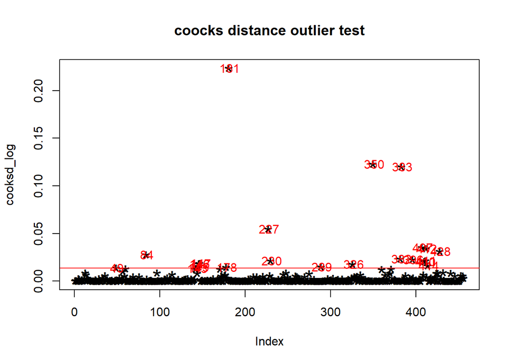

```r
cooksd_log <- cooks.distance(rey_del_model_log)
plot(cooksd_log, pch="*", cex=2, main='coocks distance outlier test')
abline(h=4*mean(cooksd_log, na.rm=T), col="red")
text(x=1:length(cooksd_log)+1, y=cooksd_log, labels=ifelse(cooksd_log>4*mean(cooksd_log, na.rm=T), names(cooksd_log), ""), col="red")
```

> 해당 그래프에 따르면 굉장히 많은 outlier들이 관찰되는것을 알 수있다.

#### 2.6 다음은 `Leverage Test`를 진행하겠다.

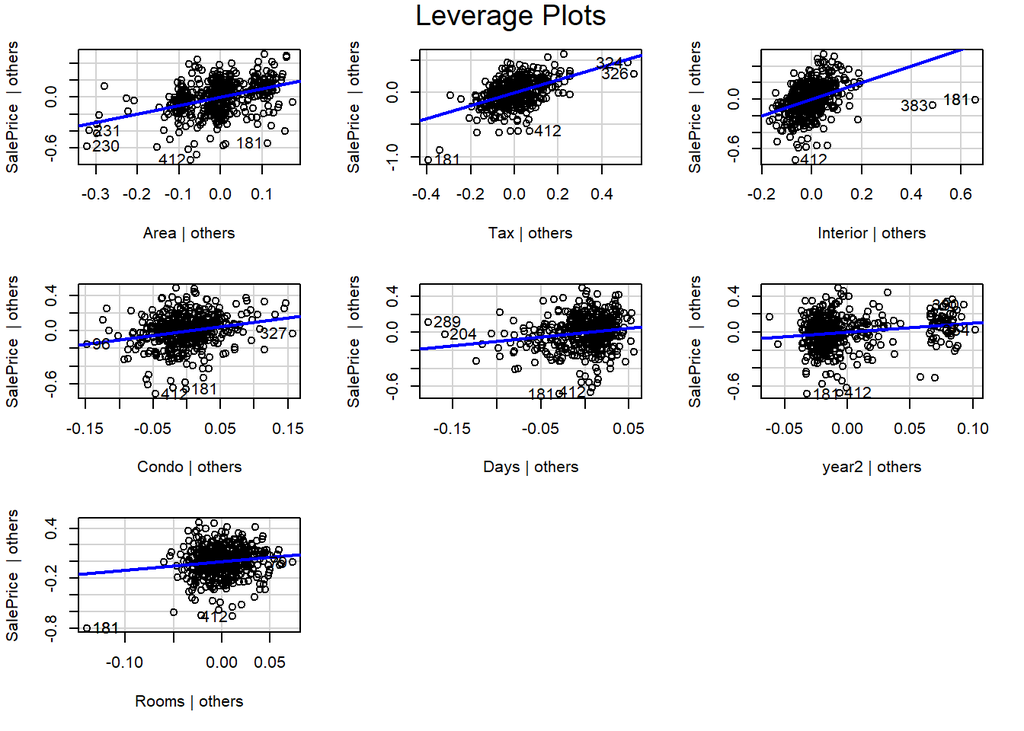

```r
k = length(rey_del_model_log$coefficients)
n = length(rey_del_cbind2)
leverage_point=3*sqrt((25+1)/(456-25-1))
leveragePlots(rey_del_model_log)
```

#### 2.7 관측된 `Leverage와 Outlier`를 제거하겠다.

```r
library(Rfit)
names(rey_del_cbind)
```

```
##  [1] "Area"       "FirstPrice" "LastPrice"  "SalePrice"  "CloseDate"
##  [6] "Days"       "Interior"   "Bed"        "Bath"       "Rooms"
## [11] "Condo"      "Tax"        "RC"         "year2"
```

```r
outlier = cbind(subset(rey_del_cbind2, abs(rstudent(rey_del_model_log))>=3), subset(rstudent(rey_del_model_log), abs(rstudent(rey_del_model_log))>=3))
outlier
```

```
##     Area FirstPrice LastPrice SalePrice  CloseDate Days Interior Bed Bath Rooms
## 181   RS     124500    124500  11.65269 1991-06-21  102     2568   2    1     5
## 382    E      74000     69000  11.09741 1993-03-14  162      740   2    1     4
## 383    N     315000    315000  12.57764 1990-06-29   89     3260   4    2     9
## 407    K     225000    119000  11.56172 1991-05-21  105     1253   2    2     4
## 411    K     119000    119000  11.65269 1993-08-06   83     1158   2    2     5
## 412    K     115000    100000  11.17044 1993-09-30  112      841   2    2     4
## 432   HS     119900    104900  11.35041 1990-12-13  132      895   2    1     4
##     Condo  Tax RC year2
## 181    53  547  1  1991
## 382    85  379  0  1993
## 383   150 1928  1  1990
## 407   274 2186  0  1991
## 411   253 2323  0  1993
## 412   184 1689  0  1993
## 432   170 1195  1  1990
##     subset(rstudent(rey_del_model_log), abs(rstudent(rey_del_model_log)) >=
## 181                                                                -4.206404
## 382                                                                -3.141195
## 383                                                                -3.459464
## 407                                                                -3.548236
## 411                                                                -3.054582
## 412                                                                -3.812771
## 432                                                                -3.212237
```

```r
clear_outlier=cbind(subset(rey_del_cbind2, abs(rstudent(rey_del_model_log))<=3), subset(rstudent(rey_del_model_log), abs(rstudent(rey_del_model_log))<=3))

leverage = cbind(subset(rey_del_cbind2, abs(dffits(rey_del_model_log))>=leverage_point), subset(dffits(rey_del_model_log), abs(dffits(rey_del_model_log))>=leverage_point))
leverage
```

```
##     Area FirstPrice LastPrice SalePrice  CloseDate Days Interior Bed Bath Rooms
## 84     C     189000    112000  11.62625 1991-11-26  283      920   2    1     5
## 181   RS     124500    124500  11.65269 1991-06-21  102     2568   2    1     5
## 227   SH     182000    149000  11.87060 1991-07-31  262     1130   2    1     5
## 350    C     170000    170000  11.93819 1993-08-05  103     2249   4    3     7
## 382    E      74000     69000  11.09741 1993-03-14  162      740   2    1     4
## 383    N     315000    315000  12.57764 1990-06-29   89     3260   4    2     9
## 396   NW     257000    229000  12.30138 1993-07-15  369     1425   2    2     5
## 407    K     225000    119000  11.56172 1991-05-21  105     1253   2    2     4
## 411    K     119000    119000  11.65269 1993-08-06   83     1158   2    2     5
## 412    K     115000    100000  11.17044 1993-09-30  112      841   2    2     4
## 428   NW     127900    119900  11.60824 1990-11-30  110     1000   2    1     4
##     Condo  Tax RC year2
## 84    100  585  1  1991
## 181    53  547  1  1991
```

[output cut: 21 more lines]

```r
clear_outlier_leverage=cbind(subset(clear_outlier, abs(dffits(rey_del_model_log))<=leverage_point),
subset(dffits(rey_del_model_log),
abs(dffits(rey_del_model_log))<=leverage_point))
dim(rey_del_cbind2)
```

```
## [1] 456  14
```

```r
dim(clear_outlier_leverage)
```

```
## [1] 445  16
```

> `outlier`는 총 `11`개가 제거되었으며 제거한 데이터를 기준으로 다시 분석을 실시 하였다.

#### 3. FInal Model

```r
start.model = lm(data=clear_outlier_leverage, SalePrice ~ Area)
stepAIC(start.model, scope=list(upper=~Area+year2+Days+Interior+Condo+Tax+RC+Bed+Bath+Rooms, lower=~Area), direction='both')
```

```
## Start:  AIC=-831.46
## SalePrice ~ Area
##
##            Df Sum of Sq    RSS      AIC
## + Interior  1    41.769 19.230 -1335.08
## + Tax       1    39.233 21.766 -1280.82
## + Rooms     1    24.029 36.970 -1048.78
## + Bed       1    21.891 39.108 -1024.16
## + Condo     1    18.695 42.304  -989.75
## + Bath      1    16.445 44.554  -967.06
## + RC        1     3.375 57.624  -854.39
## <none>                  60.999  -831.46
## + Days      1     0.226 60.773  -831.08
## + year2     4     0.164 60.835  -824.63
##
## Step:  AIC=-1335.08
## SalePrice ~ Area + Interior
##
##            Df Sum of Sq    RSS      AIC
## + Tax       1     6.626 12.605 -1518.09
## + Condo     1     4.544 14.686 -1451.15
## + Rooms     1     0.345 18.885 -1341.00
## + RC        1     0.320 18.910 -1340.43
## + Bed       1     0.223 19.007 -1338.18
## + Days      1     0.169 19.062 -1336.93
## + year2     4     0.356 18.874 -1335.26
## <none>                  19.230 -1335.08
## + Bath      1     0.068 19.163 -1334.62
## - Interior  1    41.769 60.999  -831.46
##
## Step:  AIC=-1518.09
## SalePrice ~ Area + Interior + Tax
##
##            Df Sum of Sq    RSS     AIC
## + year2     4    0.7532 11.851 -1537.1
## + Days      1    0.5359 12.069 -1535.1
## + Condo     1    0.4287 12.176 -1531.2
## + Bed       1    0.0591 12.545 -1518.2
## <none>                  12.604 -1518.1
## + Rooms     1    0.0121 12.592 -1516.5
```

[output cut: 34 more lines]

```
##
## Step:  AIC=-1567.87
## SalePrice ~ Area + Interior + Tax + year2 + Condo + Days
##
##            Df Sum of Sq    RSS     AIC
## <none>                  10.946 -1567.9
## + Bath      1    0.0441 10.902 -1567.6
## + Bed       1    0.0081 10.938 -1566.2
## + Rooms     1    0.0064 10.940 -1566.1
## + RC        1    0.0007 10.946 -1565.9
## - Days      1    0.4647 11.411 -1551.7
## - Condo     1    0.4706 11.417 -1551.4
## - year2     4    0.6660 11.612 -1550.0
## - Tax       1    2.8309 13.777 -1469.1
## - Interior  1    8.8850 19.831 -1309.6
```

```
##
## Call:
## lm(formula = SalePrice ~ Area + Interior + Tax + year2 + Condo +
##     Days, data = clear_outlier_leverage)
##
## Coefficients:
## (Intercept)       AreaAH        AreaC       AreaCP        AreaE       AreaFP
##  11.1042159    0.0942573   -0.4558556   -0.1489599    0.1393894   -0.1233098
##      AreaHS        AreaK        AreaM        AreaN       AreaNW       AreaPS
##   0.0171438    0.0461736   -0.0366294   -0.1552880   -0.0893910   -0.1565967
##      AreaRA       AreaRS       AreaSH        AreaW     Interior          Tax
##   0.0872405   -0.0433254   -0.3652234   -0.0439763    0.0006660    0.0001725
##   year21991    year21992    year21993    year21994        Condo         Days
##  -0.1098223   -0.1222271   -0.1143664   -0.0882404    0.0005031   -0.0002418
```

> 모델이 수정되어 `SalePrice ~ Area + Interior + Tax + year2 + Condo + Days` 모델이 가장 AIC값이 낮게 나온다.

#### 3.1 Residual Test

#### 수정된 모델의 잔차분석결과는 다음과 같다.

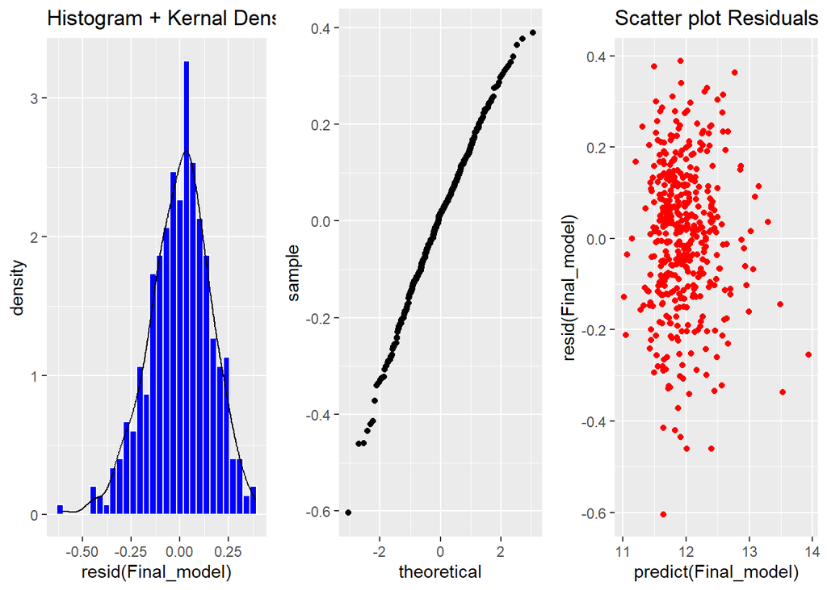

```r
Final_model=lm(data=clear_outlier_leverage, SalePrice ~ Area + Interior + Tax + year2 + Condo + Days)

p1 = ggplot(Final_model, aes(resid(Final_model), y=..density..)) +     geom_histogram(fill='blue', colour='white')+
  geom_density(fill=NA, colour=NA)+
  geom_line(stat="density")+
  ggtitle('Histogram + Kernal Density Curve Residual')

p2 = ggplot(Final_model, aes(x=predict(Final_model), y=resid(Final_model))) +
  geom_point(colour="red")+
  ggtitle('Scatter plot Residuals')
p3 = ggplot(Final_model, aes(sample=resid(Final_model))) +
  stat_qq()

grid.arrange(p1, p3, p2, ncol=3)
```

```r
shapiro.test(resid(Final_model))
```

```
##
##  Shapiro-Wilk normality test
##
## data:  resid(Final_model)
## W = 0.99239, p-value = 0.02491
```

```r
library(car)
ncvTest(Final_model)
```

```
## Non-constant Variance Score Test
## Variance formula: ~ fitted.values
## Chisquare = 0.2696385, Df = 1, p = 0.60357
```

$Log(SalesPrice)= Area + Year + Interior + Tax + Condo + Days$|

```r
summary(Final_model)
```

```
##
## Call:
## lm(formula = SalePrice ~ Area + Interior + Tax + year2 + Condo +
##     Days, data = clear_outlier_leverage)
##
## Residuals:
##      Min       1Q   Median       3Q      Max
## -0.60401 -0.10357  0.01551  0.10931  0.38919
##
## Coefficients:
##               Estimate Std. Error t value Pr(>|t|)
## (Intercept)  1.110e+01  6.172e-02 179.900  < 2e-16 ***
## AreaAH       9.426e-02  5.675e-02   1.661   0.0975 .
## AreaC       -4.559e-01  1.079e-01  -4.224 2.96e-05 ***
## AreaCP      -1.490e-01  6.035e-02  -2.468   0.0140 *
## AreaE        1.394e-01  6.018e-02   2.316   0.0210 *
## AreaFP      -1.233e-01  1.266e-01  -0.974   0.3307
## AreaHS       1.714e-02  5.357e-02   0.320   0.7491
## AreaK        4.617e-02  6.540e-02   0.706   0.4806
## AreaM       -3.663e-02  5.171e-02  -0.708   0.4791
## AreaN       -1.553e-01  6.632e-02  -2.342   0.0197 *
## AreaNW      -8.939e-02  8.880e-02  -1.007   0.3147
## AreaPS      -1.566e-01  6.496e-02  -2.411   0.0164 *
## AreaRA       8.724e-02  5.662e-02   1.541   0.1241
## AreaRS      -4.333e-02  6.868e-02  -0.631   0.5285
## AreaSH      -3.652e-01  8.946e-02  -4.082 5.35e-05 ***
## AreaW       -4.398e-02  5.703e-02  -0.771   0.4411
## Interior     6.660e-04  3.633e-05  18.331  < 2e-16 ***
## Tax          1.725e-04  1.667e-05  10.347  < 2e-16 ***
## year21991   -1.098e-01  2.750e-02  -3.993 7.71e-05 ***
## year21992   -1.222e-01  2.766e-02  -4.419 1.27e-05 ***
## year21993   -1.144e-01  2.536e-02  -4.509 8.49e-06 ***
## year21994   -8.824e-02  3.443e-02  -2.563   0.0107 *
## Condo        5.031e-04  1.192e-04   4.219 3.02e-05 ***
## Days        -2.418e-04  5.769e-05  -4.192 3.38e-05 ***
## ---
## Signif. codes:  0 '***' 0.001 '**' 0.01 '*' 0.05 '.' 0.1 ' ' 1
##
## Residual standard error: 0.1626 on 414 degrees of freedom
##   (결측으로 인하여 7개의 관측치가 삭제되었습니다.)
## Multiple R-squared:  0.8586, Adjusted R-squared:  0.8508
## F-statistic: 109.3 on 23 and 414 DF,  p-value: < 2.2e-16
```

```r
reyeme = data.frame(Area='M', year2='1994', Interior = 1040, Tax = 1121, Condo = 175, Days = 23)
reyeme_house = predict(Final_model, newdata=reyeme, interval='confidence')
exp(reyeme_house)
```

```
##        fit      lwr      upr
## 1 154474.4 145040.3 164522.2
```

> 최종 결과는 다음과 같다

| Lower | Fit | Upper |
| --- | --- | --- |
| **145040** | **154474** | **164522** |

> 따라서 `reyeme`는 주택을 구매할 경우 위 가격을 고려하여 의사결정을 실시해야한다.